# MUSSEL ABM - Cluster Output Summary

Serra Örey

Last compiled on 08 February, 2023

On 08 February, 2023 I worked on(and if you are at the html possibly knitted) this script.

Here is a R Markdown script(or the output) for:  
*summary document for Orey et.al. outputs to use in Mussel ABM*

Please follow the *table of content (outline)* for keeping track of the steps. It must be on the left side.

Statistical tests for the explanatory variables.

# 1. Housekeeping

Check the needed packages:

```r
#check Rversion:
R.version.string
```

```
## [1] "R version 4.0.2 (2020-06-22)"
```

```r
#important for rmarkdown
knitr::opts_chunk$set(echo = T, eval = T, fig.keep="all",cache = T) #DEFAULT:echo = T, eval = T, #eval=F does not run the code
knitr::opts_knit$set(root.dir = "M:/01_Projects/")
#getwd()

#housekeeping
##packages####
options(rlib_downstream_check = FALSE) #dont check package downstream

library(scales) #for show_col
library(patchwork)
library(tidyverse)
library(cowplot)
#library(tidyr, lib.loc = "/usr/lib/R/site-library")

#require(parallel)
#require(doParallel)
#require(foreach)

#require(sp)
#require(sf)
#require(rnaturalearth)

library(MetBrewer)
library(knitr)

#library(factoextra)
library(RColorBrewer)

#library(cluster)



#require(cluster)
#require(chron)
require("factoextra") #visualization with clustering and pca
#require(maps)

library(ggcorrplot)
library(jmv) #for frequency table
library(nnet)

library(ggstatsplot)
library(Rcpp)
```

Paths, parameters…

```r
my_project<-"221122-1stmanu_stat_trial"

#paths####
#data_main<- "~/shared_vmsdata/"; #update for local laptop

data_in<- paste0("M:/01_Projects/",my_project,"/data_in/")
data_out<-paste0("M:/01_Projects/",my_project,"/data_out/")

#parameters####
#prj<-"+proj=longlat +datum=WGS84 +no_defs +ellps=WGS84 +towgs84=0,0,0" #map projection
#prj<-"+proj=utm +zone=32 +ellps=GRS80 +towgs84=0,0,0,0,0,0,0 +units=m +no_defs +type=crs" #map projection FOR CALCULATIONS #https://epsg.io/25832
#prj2<-sf::st_crs("EPSG:25832")
#proj4string = CRS(prj)

t_today=format(Sys.time(), '%y%m%d')


#latlon to zoom
#zolon = c(5, 9)
#zolat = c(53.2, 55)

#latlon to super zoom
#zozolon = c(7, 9)
#zozolat = c(53.5, 54.3)

#my_lon = c(2.5, 9.3)
#my_lat = c(51, 57)
```

Fancy color picking chunk.

```r
#display_all(sequential = FALSE, colorblind_only = TRUE)
#met.brewer("Archambault", 9)

#met.brewer("Veronese", 12) #

serra<-c(met.brewer("Veronese", 12)[1],
         met.brewer("Veronese", 12)[5],
         met.brewer("Veronese", 12)[9],
         met.brewer("Veronese", 12)[12])

#I am assigning cluster ID names to colors! (this was designed in a previous script)
names(serra)<-factor(c(4,3,2,1))

#scales::show_col(serra)


#serra<-c('#332288', '#AA4499', '#44AA99')
#require(scales)
#q_colors =  4 # for no particular reason
#v_colors =  viridis(q_colors, option = "B")
#rev(v_colors)
```

# 2. Data Loading

Loading part:  
I am loading R files from previous step.

I calculated the aggregated values already in project: 220525-repating_HR_calculations.  
They are per year per vessel level. And I copied that file to data_in of my new project “221022-clustering_pca”.

It is already merged on *221124* and *221125*.

file:///R:/R/01_Projects/221022-clustering_pca/code/3-1-plot-final_graphs

parameter name explains the aggregation for parameters used in clustering:

perves_f_trait_df <- perves_f_trait_df %>% rename(mean.core_area_index=mean.mean_hr50, sd.core_area_index=sd.mean_hr50, mean.area_flexibility=mean.mean_hrchange_rel, sd.area_flexibility=sd.mean_hrchange_rel, mean.total_fishinghours=mean.sum_fishinghours, sd.total_fishinghours=sd.sum_fishinghours, mean.triplength=mean.mean_triplength, sd.triplength=sd.mean_triplength, mean.distance_to_port=mean.dist_to_DHAR, sd.distance_to_port=sd.dist_to_DHAR)

```r
df_to_explain<-readRDS(file = paste0(data_in,"perves-merged_explanatory-","221124",".rds"))
#f_trait_df-perves-ves_clusters-221125
df_to_cluster<-readRDS(file = paste0(data_in,"f_trait_df-perves-ves_clusters-","221125",".rds"))
```

# 3. Data Wrangling

## 3.cluster

## 3.explain

```r
colnames(df_to_explain)
```

```
##  [1] "VE_REF"            "sub_grp"           "LE_KG_CSH"
##  [4] "pp_tot_kgs"        "eff_hrs"           "LPUE"
##  [7] "other_catch"       "perc_csh"          "Other Gear"
## [10] "TBB_CRU_16-31_0_0" "per_metcra"        "VE_LEN"
## [13] "VE_KW"             "VE_TON"            "fav_dep"
## [16] "fav_lan"           "VE_HOME"
```

```r
#all
my_parameters<-c("VE_REF","sub_grp",
                 "LE_KG_CSH","pp_tot_kgs","eff_hrs","LPUE","other_catch","perc_csh",
                 "Other Gear","TBB_CRU_16-31_0_0","per_metcra",
                 "VE_LEN","VE_KW","VE_TON","fav_dep","fav_lan","VE_HOME")

#only continuous without harbors
my_parameters<-c("VE_REF","sub_grp",
                 "LE_KG_CSH","pp_tot_kgs","eff_hrs","LPUE","other_catch","perc_csh",
                 "Other Gear","TBB_CRU_16-31_0_0","per_metcra",
                 "VE_LEN","VE_KW","VE_TON")

df_merged_sub <- df_to_explain %>% dplyr::select(all_of(my_parameters))
```

Check correlation.

```r
perves_f_trait_df<-df_merged_sub

#str(perves_f_trait_df)
summary(perves_f_trait_df)
```

```
##     VE_REF          sub_grp   LE_KG_CSH          pp_tot_kgs
##  Length:211         4: 12   Min.   :   385.2   Min.   :   385.2
##  Class :character   3:119   1st Qu.: 38158.2   1st Qu.: 42566.9
##  Mode  :character   2: 17   Median : 60788.4   Median : 64374.5
##                     1: 63   Mean   : 62183.3   Mean   : 71923.5
##                             3rd Qu.: 82508.8   3rd Qu.: 86809.9
##                             Max.   :151993.0   Max.   :359796.8
##     eff_hrs             LPUE           other_catch          perc_csh
##  Min.   :  48.63   Min.   :  0.9254   Min.   :     0.0   Min.   :0.01918
##  1st Qu.: 878.76   1st Qu.: 37.7449   1st Qu.:     0.0   1st Qu.:0.99864
##  Median :1351.27   Median : 46.7274   Median :     4.2   Median :0.99993
##  Mean   :1401.46   Mean   : 48.3771   Mean   :  9740.3   Mean   :0.95024
##  3rd Qu.:1814.53   3rd Qu.: 57.8626   3rd Qu.:    88.9   3rd Qu.:1.00000
##  Max.   :3685.15   Max.   :111.5714   Max.   :357240.7   Max.   :1.00000
##    Other Gear       TBB_CRU_16-31_0_0   per_metcra          VE_LEN
##  Min.   :    0.00   Min.   :  145.9   Min.   :0.02774   Min.   :12.35
##  1st Qu.:    0.00   1st Qu.: 7783.8   1st Qu.:0.99386   1st Qu.:15.95
##  Median :    7.67   Median :14462.3   Median :0.99940   Median :17.24
##  Mean   : 1233.04   Mean   :14784.6   Mean   :0.94863   Mean   :18.09
##  3rd Qu.:  109.12   3rd Qu.:21952.0   3rd Qu.:1.00000   3rd Qu.:19.36
##  Max.   :44714.63   Max.   :41026.4   Max.   :1.00000   Max.   :25.27
##      VE_KW           VE_TON
##  Min.   :110.0   Min.   : 10.00
##  1st Qu.:184.5   1st Qu.: 28.00
##  Median :216.9   Median : 38.00
##  Mean   :203.3   Mean   : 49.03
##  3rd Qu.:221.0   3rd Qu.: 59.00
##  Max.   :304.8   Max.   :167.25
```

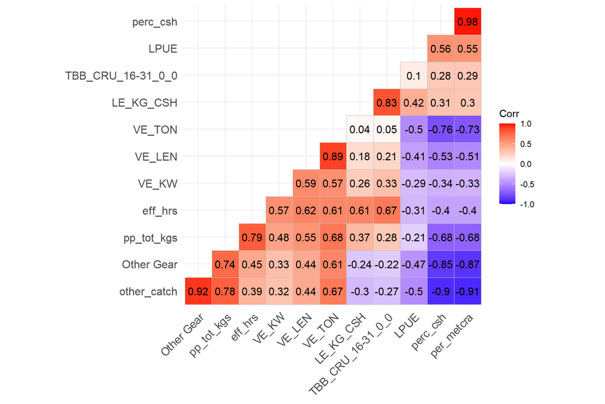

```r
#correlation matrix
my_corr <- cor(perves_f_trait_df[,3:ncol(perves_f_trait_df)],method = "pearson")


ggcorrplot(my_corr, hc.order = TRUE, type = "lower",
   lab = TRUE)
```

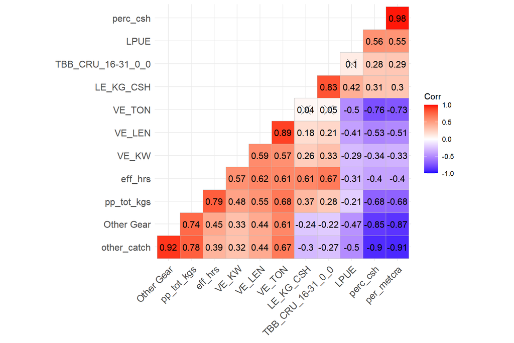

```r
# Compute a matrix of correlation p-values
p.mat <- cor_pmat(perves_f_trait_df[,3:ncol(perves_f_trait_df)])
ggcorrplot(my_corr, hc.order = TRUE, type = "lower",
   lab = TRUE, p.mat = p.mat)
```

deciding what parameters to put in cluster

```r
#selected
my_parameters<-c("VE_REF","sub_grp",
                 "LE_KG_CSH","LPUE","other_catch",
                 "VE_LEN","VE_KW")

df_merged_sub <- df_to_explain %>% dplyr::select(my_parameters)
perves_f_trait_df<-df_merged_sub


#str(perves_f_trait_df)
summary(perves_f_trait_df)
```

```
##     VE_REF          sub_grp   LE_KG_CSH             LPUE
##  Length:211         4: 12   Min.   :   385.2   Min.   :  0.9254
##  Class :character   3:119   1st Qu.: 38158.2   1st Qu.: 37.7449
##  Mode  :character   2: 17   Median : 60788.4   Median : 46.7274
##                     1: 63   Mean   : 62183.3   Mean   : 48.3771
##                             3rd Qu.: 82508.8   3rd Qu.: 57.8626
##                             Max.   :151993.0   Max.   :111.5714
##   other_catch           VE_LEN          VE_KW
##  Min.   :     0.0   Min.   :12.35   Min.   :110.0
##  1st Qu.:     0.0   1st Qu.:15.95   1st Qu.:184.5
##  Median :     4.2   Median :17.24   Median :216.9
##  Mean   :  9740.3   Mean   :18.09   Mean   :203.3
##  3rd Qu.:    88.9   3rd Qu.:19.36   3rd Qu.:221.0
##  Max.   :357240.7   Max.   :25.27   Max.   :304.8
```

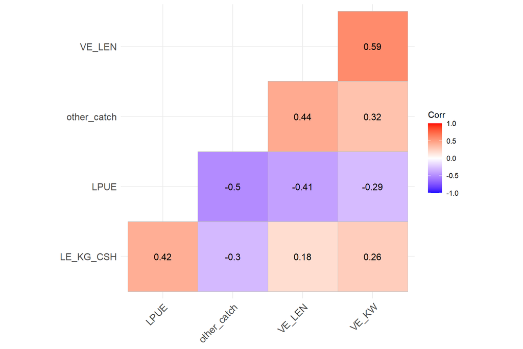

```r
#correlation matrix
my_corr <- cor(perves_f_trait_df[,3:ncol(perves_f_trait_df)],method = "pearson")


ggcorrplot(my_corr, hc.order = TRUE, type = "lower",
   lab = TRUE)
```

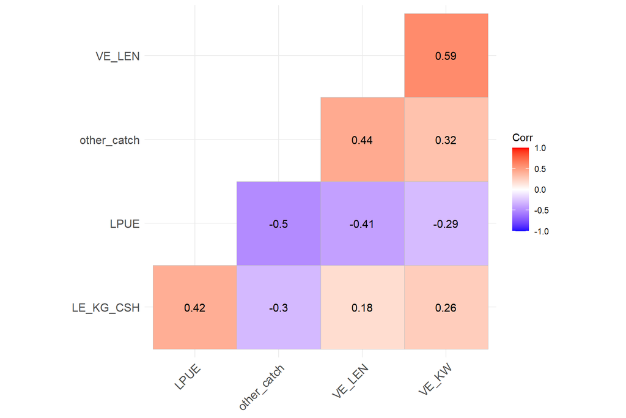

```r
# Compute a matrix of correlation p-values
p.mat <- cor_pmat(perves_f_trait_df[,3:ncol(perves_f_trait_df)])
ggcorrplot(my_corr, hc.order = TRUE, type = "lower",
   lab = TRUE, p.mat = p.mat)
```

I am omitting harbor for the first try choosing only:LE_KG_CSH,LPUE, other_catch, VE_LEN, VE_KW

It would be nice to have vessel built year. but I do not have it at the moment.

```r
df_stat<-df_to_explain %>% dplyr::select(c(sub_grp,LE_KG_CSH,LPUE, other_catch, VE_LEN, VE_KW))

#order levels to plot  1234
df_stat$sub_grp <- factor(df_stat$sub_grp, levels = 1:4)
```

##3.harbors harbor aggragation is recorded. number of vessels per cluster are calculated.

```r
df_merged<-df_to_explain
df_merged$fav_lan<-as.factor(df_merged$fav_lan)
levels(df_merged$fav_lan)
```

```
##  [1] "DEACC" "DEBEN" "DEBRV" "DEBUM" "DECUX" "DEDAG" "DEDIT" "DEDRM" "DEEIK"
## [10] "DEFES" "DEGRE" "DEHHF" "DEHOO" "DEHSX" "DEHUS" "DENHS" "DENOE" "DENOR"
## [19] "DEPEL" "DESCY" "DESKW" "DETOE" "DEVAR" "DEWRY" "DEWYK" "DKHNB" "DKRNN"
## [28] "NLDHR" "NLHAR" "NLLAN"
```

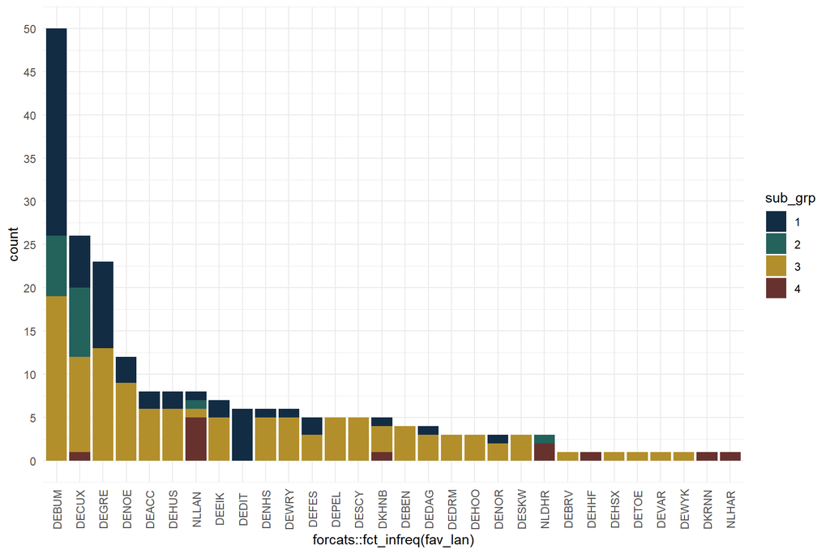

```r
#str(df_merged)

#order levels to plot  1234
df_merged$sub_grp <- factor(df_merged$sub_grp, levels = 1:4)

ggplot()+
  geom_bar(data=df_merged,aes(x=forcats::fct_infreq(fav_lan),fill=sub_grp))+
  scale_fill_manual(values = serra) +
  scale_y_continuous(breaks = seq(0, 50, by = 5))+
  theme_minimal()+
  theme(axis.text.x = element_text(angle = 90, vjust = 0.5))
```

```r
#get an output table for number of vessels per port
temp_df<-df_merged %>%
  group_by(sub_grp,fav_lan) %>%
  summarise(n_vessels = n())
write_csv(temp_df,file = paste0(data_out,"musselabm-","harbor_vessel",".csv"))
```

# 4. Plots

detailed example

## 4.cluster

is data normally dist?

```r
df_to_cluster
```

```
## # A tibble: 211 x 7
##    VE_REF       core_area_index area_flexibility total~1 tripl~2 dista~3 sub_grp
##    <chr>                  <dbl>            <dbl>   <dbl>   <dbl>   <dbl> <fct>
##  1 BEL011101959            919.             3.18   1252.   26.0   82443. 1
##  2 DEU000070400            515.             3.41    690.   40.6  102810. 2
##  3 DEU000070500            164.             3.06    716.    9.61  23696. 3
##  4 DEU000160300            109.             2.99    587.    6.60  19190. 3
##  5 DEU000200500            338.             3.45    912.   28.9  166331. 4
##  6 DEU000210300            108.             2.92    331.    6.87  20154. 3
##  7 DEU000270300            878.             3.31   1607.   41.8  110384. 2
##  8 DEU000290300           2644.             3.53   3515.   69.0  153246. 2
##  9 DEU000340500           1388.             3.30    937.   40.0  112494. 2
## 10 DEU000350300            165.             2.98    730.    8.65  29170. 3
## # ... with 201 more rows, and abbreviated variable names 1: total_fishinghours,
## #   2: triplength, 3: distance_to_port
```

```r
shapiro.test(df_to_cluster$core_area_index)
```

```
##
##  Shapiro-Wilk normality test
##
## data:  df_to_cluster$core_area_index
## W = 0.55363, p-value < 2.2e-16
```

```r
shapiro.test(df_to_cluster$area_flexibility)
```

```
##
##  Shapiro-Wilk normality test
##
## data:  df_to_cluster$area_flexibility
## W = 0.97738, p-value = 0.001784
```

```r
shapiro.test(df_to_cluster$total_fishinghours)
```

```
##
##  Shapiro-Wilk normality test
##
## data:  df_to_cluster$total_fishinghours
## W = 0.97756, p-value = 0.001892
```

```r
shapiro.test(df_to_cluster$triplength)
```

```
##
##  Shapiro-Wilk normality test
##
## data:  df_to_cluster$triplength
## W = 0.92417, p-value = 5.836e-09
```

```r
shapiro.test(df_to_cluster$distance_to_port)
```

```
##
##  Shapiro-Wilk normality test
##
## data:  df_to_cluster$distance_to_port
## W = 0.72211, p-value < 2.2e-16
```

Choose NON-PARAMETRIC TEST.

```r
summary(df_to_cluster)
```

```
##     VE_REF          core_area_index   area_flexibility total_fishinghours
##  Length:211         Min.   :  25.77   Min.   :2.759    Min.   :  48.63
##  Class :character   1st Qu.: 149.98   1st Qu.:3.143    1st Qu.: 878.76
##  Mode  :character   Median : 315.38   Median :3.281    Median :1351.27
##                     Mean   : 632.43   Mean   :3.283    Mean   :1401.46
##                     3rd Qu.: 727.29   3rd Qu.:3.396    3rd Qu.:1814.53
##                     Max.   :7110.31   Max.   :4.032    Max.   :3685.15
##    triplength     distance_to_port sub_grp
##  Min.   : 3.956   Min.   : 11809   1: 63
##  1st Qu.:14.466   1st Qu.: 35448   2: 17
##  Median :24.207   Median : 46652   3:119
##  Mean   :26.352   Mean   : 67452   4: 12
##  3rd Qu.:35.462   3rd Qu.: 78863
##  Max.   :82.349   Max.   :305945
```

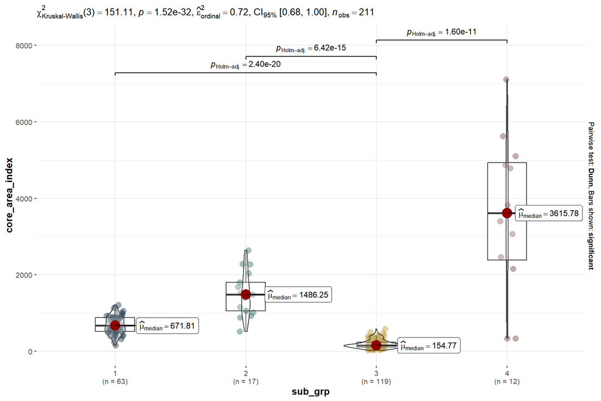

```r
#df_to_cluster %>%
#  group_by(sub_grp) %>%
#  summarise(across(2:6,
#                   list(median = median, mean = mean, sd = sd, min=min,max=max),
#                   .names = "{.col}-{.fn}"))


#
ggbetweenstats(
  data = df_to_cluster,
  x = sub_grp,
  y = core_area_index,
  type = "nonparametric"
)+
  scale_colour_manual(
  values = serra,
  )
```

```r
temp_df <- df_to_cluster %>%
  group_by(sub_grp) %>%
  summarise_at(c("core_area_index"), list(median = median, mean = mean, sd = sd, min=min,max=max))
knitr::kable(temp_df)
```

| sub_grp | median | mean | sd | min | max |
| --- | --- | --- | --- | --- | --- |
| 1 | 671.8138 | 683.3898 | 230.6545 | 154.82579 | 1208.2514 |
| 2 | 1486.2515 | 1486.9644 | 578.8590 | 515.18585 | 2643.7759 |
| 3 | 154.7685 | 184.9535 | 109.5209 | 25.77415 | 583.7084 |
| 4 | 3615.7793 | 3591.7230 | 2061.9764 | 336.71010 | 7110.3125 |

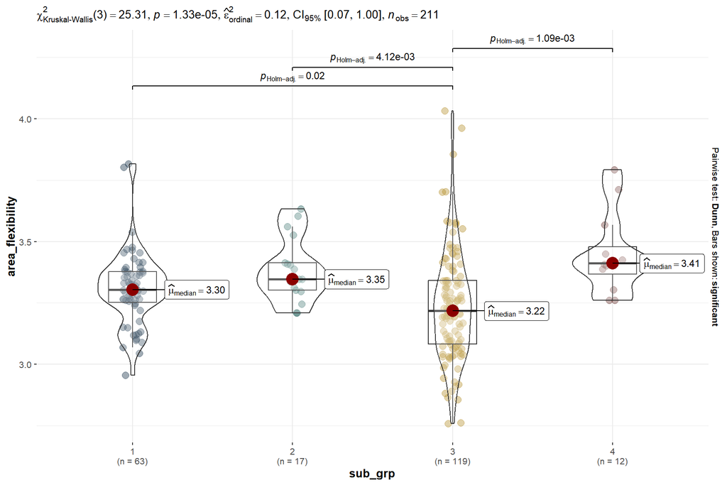

```r
write_csv(temp_df,file = paste0(data_out,"musselabm-","core_area_index",".csv"))

#
ggbetweenstats(
  data = df_to_cluster,
  x = sub_grp,
  y = area_flexibility,
  type = "nonparametric"
)+
  scale_colour_manual(
  values = serra,
  )
```

```r
temp_df <- df_to_cluster %>%
  group_by(sub_grp) %>%
  summarise_at(c("area_flexibility"), list(median = median, mean = mean, sd = sd, min=min,max=max))
knitr::kable(temp_df)
```

| sub_grp | median | mean | sd | min | max |
| --- | --- | --- | --- | --- | --- |
| 1 | 3.304568 | 3.308126 | 0.1502837 | 2.955536 | 3.816552 |
| 2 | 3.346852 | 3.385128 | 0.1295437 | 3.209747 | 3.633262 |
| 3 | 3.217691 | 3.238134 | 0.2246333 | 2.758949 | 4.031913 |
| 4 | 3.411284 | 3.449094 | 0.1655735 | 3.261499 | 3.791583 |

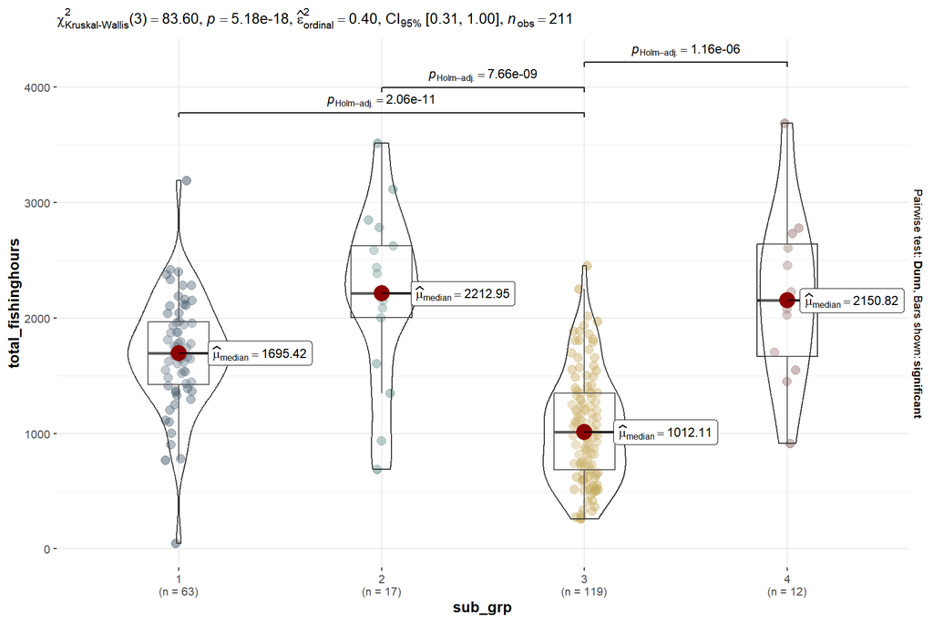

```r
write_csv(temp_df,file = paste0(data_out,"musselabm-","area_flexibility",".csv"))

#
ggbetweenstats(
  data = df_to_cluster,
  x = sub_grp,
  y = total_fishinghours,
  type = "nonparametric"
)+
  scale_colour_manual(
  values = serra,
  )
```

```r
temp_df <- df_to_cluster %>%
  group_by(sub_grp) %>%
  summarise_at(c("total_fishinghours"), list(median = median, mean = mean, sd = sd, min=min,max=max))
knitr::kable(temp_df)
```

| sub_grp | median | mean | sd | min | max |
| --- | --- | --- | --- | --- | --- |
| 1 | 1695.418 | 1695.687 | 482.9011 | 48.63333 | 3189.592 |
| 2 | 2212.949 | 2208.319 | 740.1988 | 689.68974 | 3515.372 |
| 3 | 1012.106 | 1051.525 | 471.8420 | 260.28333 | 2450.369 |
| 4 | 2150.825 | 2183.944 | 737.6611 | 911.71000 | 3685.154 |

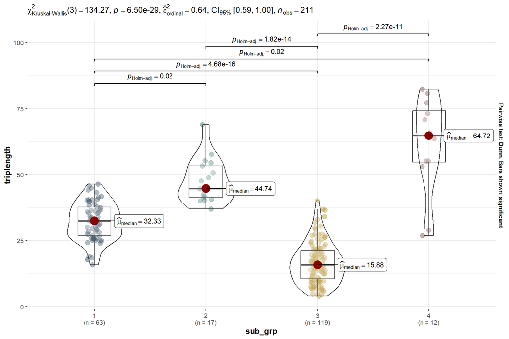

```r
write_csv(temp_df,file = paste0(data_out,"musselabm-","total_fishinghours",".csv"))

#
ggbetweenstats(
  data = df_to_cluster,
  x = sub_grp,
  y = triplength,
  type = "nonparametric"
)+
  scale_colour_manual(
  values = serra,
  )
```

```r
temp_df <- df_to_cluster %>%
  group_by(sub_grp) %>%
  summarise_at(c("triplength"), list(median = median, mean = mean, sd = sd, min=min,max=max))
knitr::kable(temp_df)
```

| sub_grp | median | mean | sd | min | max |
| --- | --- | --- | --- | --- | --- |
| 1 | 32.33045 | 32.36189 | 7.186190 | 15.892593 | 46.42073 |
| 2 | 44.73920 | 47.61776 | 8.259382 | 36.997584 | 68.95257 |
| 3 | 15.88431 | 16.63042 | 7.771796 | 3.955714 | 40.05543 |
| 4 | 64.72111 | 61.07376 | 18.352791 | 26.908756 | 82.34921 |

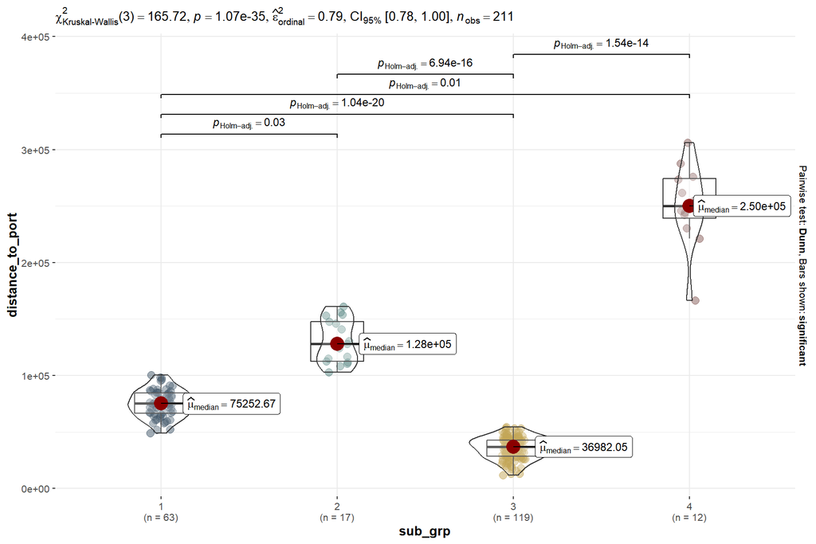

```r
write_csv(temp_df,file = paste0(data_out,"musselabm-","triplength",".csv"))

#
ggbetweenstats(
  data = df_to_cluster,
  x = sub_grp,
  y = distance_to_port,
  type = "nonparametric"
)+
  scale_colour_manual(
  values = serra,
  )
```

```r
temp_df <- df_to_cluster %>%
  group_by(sub_grp) %>%
  summarise_at(c("distance_to_port"), list(median = median, mean = mean, sd = sd, min=min,max=max))
knitr::kable(temp_df)
```

| sub_grp | median | mean | sd | min | max |
| --- | --- | --- | --- | --- | --- |
| 1 | 75252.67 | 75177.00 | 12195.914 | 48947.98 | 100426.79 |
| 2 | 128148.22 | 130562.80 | 19536.906 | 102810.47 | 161044.84 |
| 3 | 36982.05 | 35852.34 | 9810.115 | 11808.97 | 54369.99 |
| 4 | 250235.58 | 250854.21 | 36025.651 | 166330.75 | 305944.86 |

```r
write_csv(temp_df,file = paste0(data_out,"musselabm-","distance_to_port",".csv"))
```

## 4.explanatory

is data normally dist?

```r
summary(df_stat)
```

```
##  sub_grp   LE_KG_CSH             LPUE           other_catch
##  1: 63   Min.   :   385.2   Min.   :  0.9254   Min.   :     0.0
##  2: 17   1st Qu.: 38158.2   1st Qu.: 37.7449   1st Qu.:     0.0
##  3:119   Median : 60788.4   Median : 46.7274   Median :     4.2
##  4: 12   Mean   : 62183.3   Mean   : 48.3771   Mean   :  9740.3
##          3rd Qu.: 82508.8   3rd Qu.: 57.8626   3rd Qu.:    88.9
##          Max.   :151993.0   Max.   :111.5714   Max.   :357240.7
##      VE_LEN          VE_KW
##  Min.   :12.35   Min.   :110.0
##  1st Qu.:15.95   1st Qu.:184.5
##  Median :17.24   Median :216.9
##  Mean   :18.09   Mean   :203.3
##  3rd Qu.:19.36   3rd Qu.:221.0
##  Max.   :25.27   Max.   :304.8
```

```r
shapiro.test(df_stat$LE_KG_CSH)
```

```
##
##  Shapiro-Wilk normality test
##
## data:  df_stat$LE_KG_CSH
## W = 0.98396, p-value = 0.01697
```

```r
shapiro.test(df_stat$LPUE)
```

```
##
##  Shapiro-Wilk normality test
##
## data:  df_stat$LPUE
## W = 0.9701, p-value = 0.000187
```

```r
shapiro.test(df_stat$other_catch)
```

```
##
##  Shapiro-Wilk normality test
##
## data:  df_stat$other_catch
## W = 0.21393, p-value < 2.2e-16
```

```r
shapiro.test(df_stat$VE_LEN)
```

```
##
##  Shapiro-Wilk normality test
##
## data:  df_stat$VE_LEN
## W = 0.89524, p-value = 5.594e-11
```

```r
shapiro.test(df_stat$VE_KW)
```

```
##
##  Shapiro-Wilk normality test
##
## data:  df_stat$VE_KW
## W = 0.81532, p-value = 4.312e-15
```

Choose NON-PARAMETRIC TEST.

```r
colnames(df_stat)
```

```
## [1] "sub_grp"     "LE_KG_CSH"   "LPUE"        "other_catch" "VE_LEN"
## [6] "VE_KW"
```

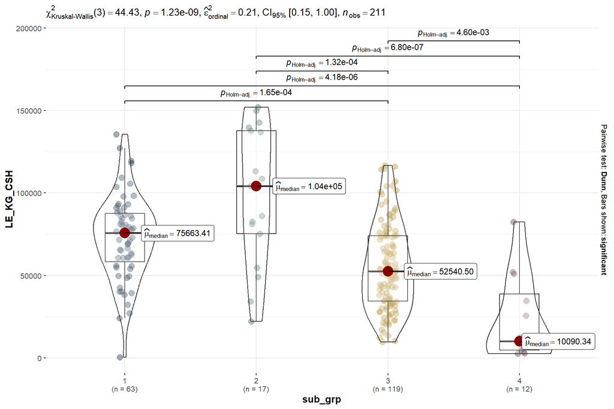

```r
ggbetweenstats(
  data = df_stat,
  x = sub_grp,
  y = LE_KG_CSH,
  type = "nonparametric"
)+
  scale_colour_manual(
  values = serra,
  )
```

```r
temp_df <- df_stat %>%
  group_by(sub_grp) %>%
  summarise_at(c("LE_KG_CSH"), list(median = median, mean = mean, sd = sd, min=min,max=max))
knitr::kable(temp_df)
```

| sub_grp | median | mean | sd | min | max |
| --- | --- | --- | --- | --- | --- |
| 1 | 75663.41 | 72918.38 | 25395.82 | 385.2318 | 135555.4 |
| 2 | 104207.80 | 98262.09 | 41902.33 | 22066.5758 | 151993.0 |
| 3 | 52540.50 | 55214.27 | 26379.00 | 9734.0182 | 116709.8 |
| 4 | 10090.34 | 23821.43 | 26042.62 | 2556.0547 | 82392.4 |

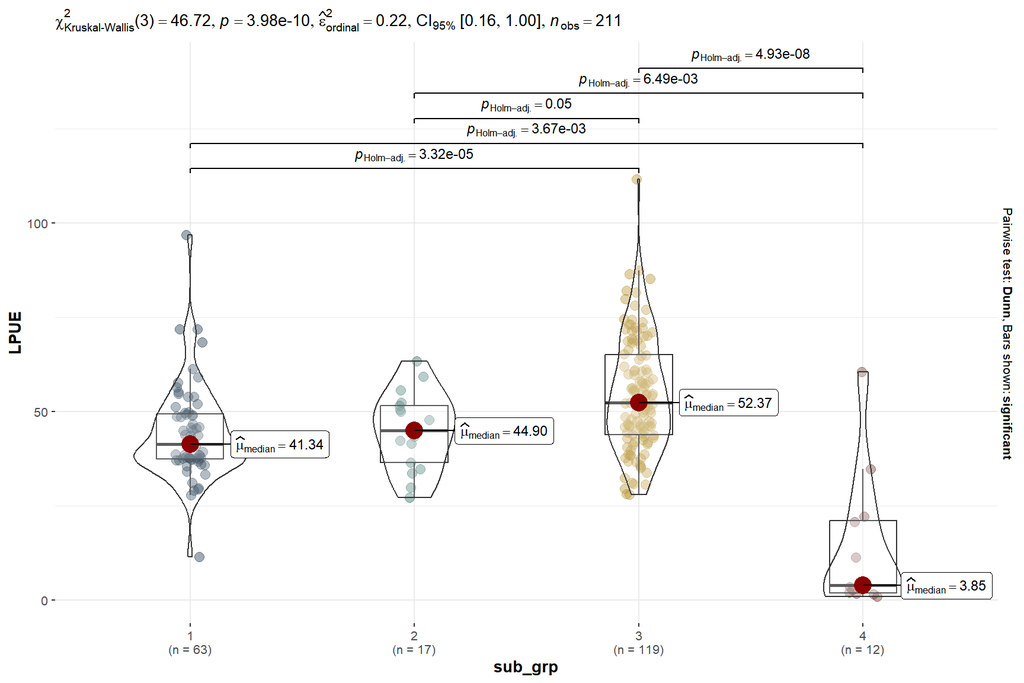

```r
write_csv(temp_df,file = paste0(data_out,"musselabm-","LE_KG_CSH",".csv"))



ggbetweenstats(
  data = df_stat,
  x = sub_grp,
  y = LPUE,
  type = "nonparametric"
)+
  scale_colour_manual(
  values = serra,
  )
```

```r
temp_df <- df_stat %>%
  group_by(sub_grp) %>%
  summarise_at(c("LPUE"), list(median = median, mean = mean, sd = sd, min=min,max=max))
knitr::kable(temp_df)
```

| sub_grp | median | mean | sd | min | max |
| --- | --- | --- | --- | --- | --- |
| 1 | 41.335974 | 44.29354 | 12.59282 | 11.4565721 | 96.83555 |
| 2 | 44.896110 | 44.93154 | 10.28313 | 27.1406127 | 63.39054 |
| 3 | 52.369771 | 54.51565 | 15.09858 | 27.9123237 | 111.57142 |
| 4 | 3.845739 | 13.82290 | 18.23795 | 0.9253936 | 60.43421 |

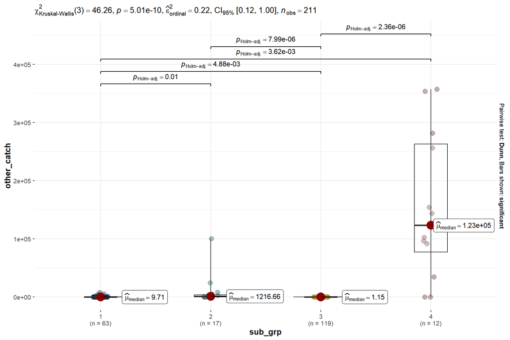

```r
write_csv(temp_df,file = paste0(data_out,"musselabm-","LPUE",".csv"))


ggbetweenstats(
  data = df_stat,
  x = sub_grp,
  y = other_catch,
  type = "nonparametric"
)+
  scale_colour_manual(
  values = serra,
  )
```

```r
temp_df <- df_stat %>%
  group_by(sub_grp) %>%
  summarise_at(c("other_catch"), list(median = median, mean = mean, sd = sd, min=min,max=max))
knitr::kable(temp_df)
```

| sub_grp | median | mean | sd | min | max |
| --- | --- | --- | --- | --- | --- |
| 1 | 9.714286e+00 | 441.01037 | 1301.7533 | 0 | 7685.1947 |
| 2 | 1.216664e+03 | 8958.99278 | 24327.3201 | 0 | 100528.7291 |
| 3 | 1.153846e+00 | 32.69259 | 92.1262 | 0 | 645.9944 |
| 4 | 1.230500e+05 | 155935.26802 | 127749.5169 | 0 | 357240.7333 |

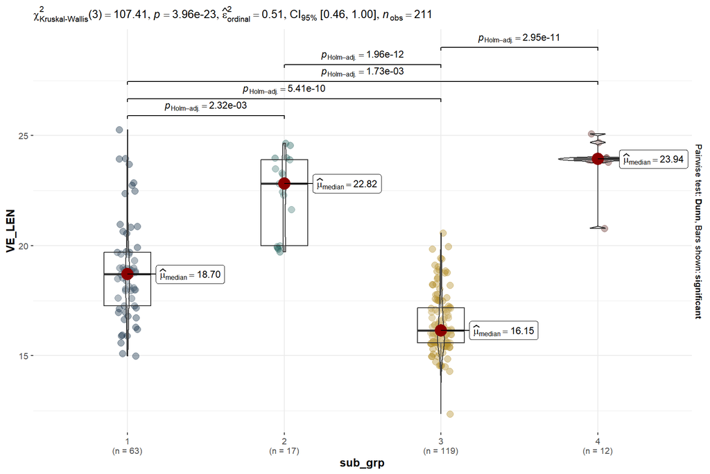

```r
write_csv(temp_df,file = paste0(data_out,"musselabm-","other_catch",".csv"))



ggbetweenstats(
  data = df_stat,
  x = sub_grp,
  y = VE_LEN,
  type = "nonparametric"
)+
  scale_colour_manual(
  values = serra,
  )
```

```r
temp_df <- df_stat %>%
  group_by(sub_grp) %>%
  summarise_at(c("VE_LEN"), list(median = median, mean = mean, sd = sd, min=min,max=max))
knitr::kable(temp_df)
```

| sub_grp | median | mean | sd | min | max |
| --- | --- | --- | --- | --- | --- |
| 1 | 18.700 | 18.86219 | 2.257809 | 14.98 | 25.2700 |
| 2 | 22.820 | 22.33722 | 1.804621 | 19.71 | 24.6500 |
| 3 | 16.150 | 16.49427 | 1.377352 | 12.35 | 20.5700 |
| 4 | 23.935 | 23.82021 | 1.029144 | 20.79 | 25.0825 |

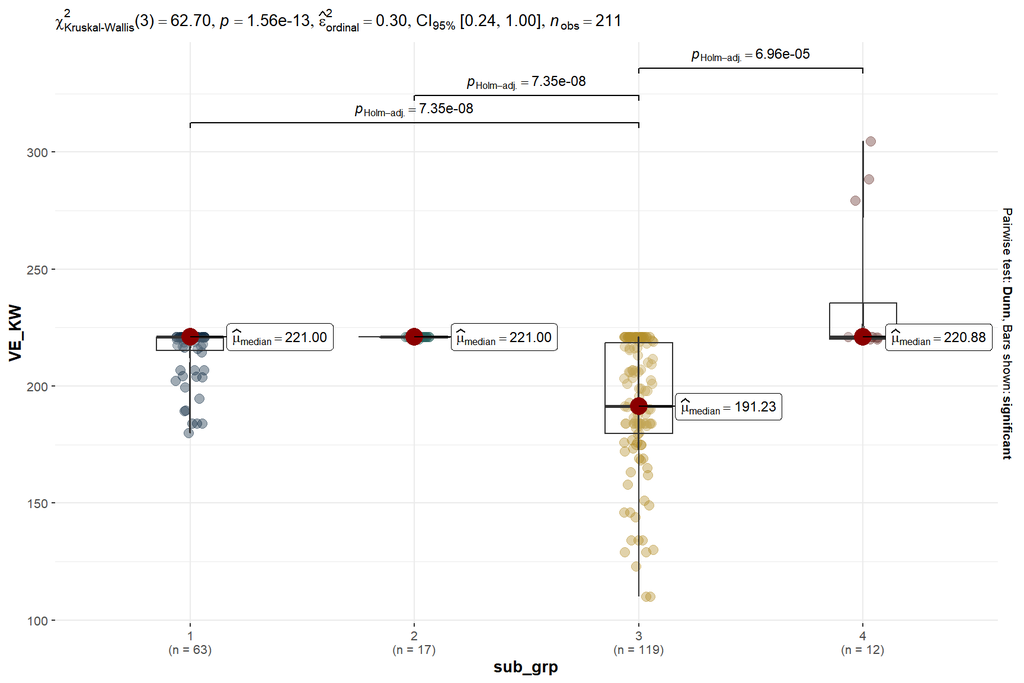

```r
write_csv(temp_df,file = paste0(data_out,"musselabm-","VE_LEN",".csv"))




ggbetweenstats(
  data = df_stat,
  x = sub_grp,
  y = VE_KW,
  type = "nonparametric"
)+
  scale_colour_manual(
  values = serra,
  )
```

```r
temp_df <- df_stat %>%
  group_by(sub_grp) %>%
  summarise_at(c("VE_KW"), list(median = median, mean = mean, sd = sd, min=min,max=max))
knitr::kable(temp_df)
```

| sub_grp | median | mean | sd | min | max |
| --- | --- | --- | --- | --- | --- |
| 1 | 221.0000 | 214.4229 | 11.4967368 | 180 | 221.00 |
| 2 | 221.0000 | 220.9412 | 0.2425356 | 220 | 221.00 |
| 3 | 191.2308 | 191.4593 | 27.8762502 | 110 | 221.00 |
| 4 | 220.8846 | 238.0663 | 32.2645524 | 220 | 304.75 |

```r
write_csv(temp_df,file = paste0(data_out,"musselabm-","VE_KW",".csv"))
```

End of the document. - Serra Örey